# 08_Explicabilidad

### Explicabilidad

Este notebook proporciona un análisis exhaustivo sobre la explicabilidad de nuestro modelo LightGBM, utilizando herramientas como SHAP (SHapley Additive exPlanations) y scikit-learn. El objetivo es profundizar en el entendimiento de cómo el modelo toma decisiones y cuál es la importancia relativa de las distintas variables en estas decisiones.

Los objetivos clave de este notebook son:

1. Profundizar en la Explicabilidad del Modelo: Utilizar SHAP para obtener una comprensión detallada de la contribución de cada variable en las predicciones del modelo.
2. Visualización de la Importancia de las Variables: Emplear herramientas de scikit-learn para visualizar y entender la relevancia de cada característica en el modelo.
3. Interpretación y Análisis: Proporcionar un análisis interpretativo de los resultados obtenidos, facilitando una mayor transparencia y confianza en el modelo.

Importamos las librerias que vamos a utilizar.

```python
import pandas as pd
import numpy as np
import matplotlib.pyplot as plt
import seaborn as sns
import pickle
import sklearn
from sklearn import metrics
#!pip install shap
from sklearn.pipeline import Pipeline
from sklearn.compose import ColumnTransformer
from xgboost import XGBClassifier
import shap
shap.initjs()
import warnings
warnings.filterwarnings('ignore')
```

Importamos los dataframes necesarios.

```python
with open('../data/X_test.pkl', 'rb') as f:
    X_test = pickle.load(f)

with open('../data/y_test.pkl', 'rb') as f:
    y_test = pickle.load(f)
```

Cargamos un modelo LightGBM pre-entrenado desde un archivo .pkl

```python
with open('../models/LGBM_entrenadoUndersampling.pkl', 'rb') as file:
    CV = pickle.load(file)
```

Este código devuelve el mejor estimador encontrado durante la búsqueda. Este estimador es una instancia del modelo con la configuración de hiperparámetros que dio los mejores resultados.

```python
lgbm_model = CV.best_estimator_.named_steps['classifier']
```

Creamos un explainer utilizando SHAP para nuestro modelo LightGBM. Esto nos permitirá descomponer y entender cómo cada característica contribuye individualmente a las predicciones del modelo, ofreciendo una visión transparente y detallada de su funcionamiento interno.

```python
explainer = shap.TreeExplainer(lgbm_model)
```

Calculamos los valores SHAP para nuestro conjunto de pruebas X_test utilizando el explainer creado anteriormente. Estos valores SHAP nos ayudan a entender la magnitud y dirección del impacto de cada característica en las predicciones del modelo.

```python
shap_values = explainer.shap_values(X_test)
```

Con shap.summary_plot, visualizamos los valores SHAP para las 10 características más importantes, proporcionando una representación gráfica que resalta cómo cada una influye en las predicciones del modelo. Esta visualización es clave para identificar las características más influyentes y cómo contribuyen a las decisiones del modelo

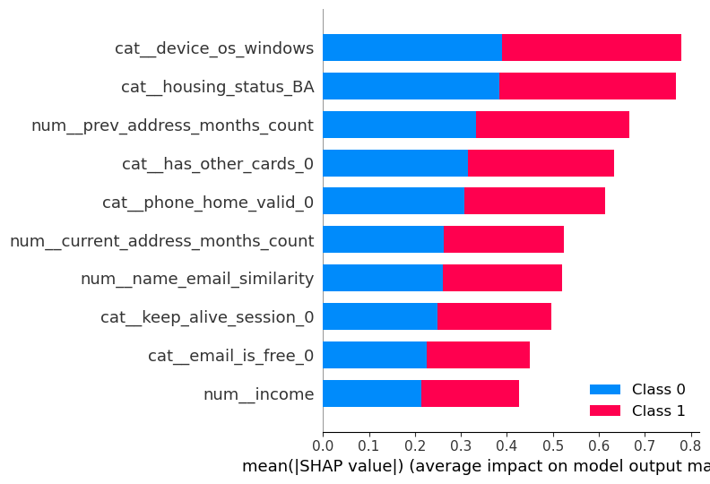

```python
shap.summary_plot(shap_values, X_test,max_display=10)
```

En esta representación gráfica, cada barra bimodal refleja la influencia de una característica individual en la clasificación del modelo entre dos clases. La porción azul de cada barra muestra la relevancia de la variable para predecir la clase 0, que en este contexto se define como casos sin fraude. Simultáneamente, la porción roja ilustra el peso de la misma variable en la determinación de la clase 1, asociada a casos de fraude. La distribución equitativa de los colores a lo largo de las barras indica que las variables tienen una importancia comparable en la modelización tanto de eventos fraudulentos como no fraudulentos.

Sin embargo income no es la variable que menos importante para el modelo ya que nosotros solamente estamos mostrando las 10 variables mas importantes para de esta forma poder sacar conclusiones sólidas en base a los datos mas relevantes. Por debajo de income hay más variables que son mucho menos importantes para el modelo.

Generamos un gráfico de resumen SHAP para la Clase 1 que visualiza el impacto de las 20 características más importantes en las predicciones del modelo.

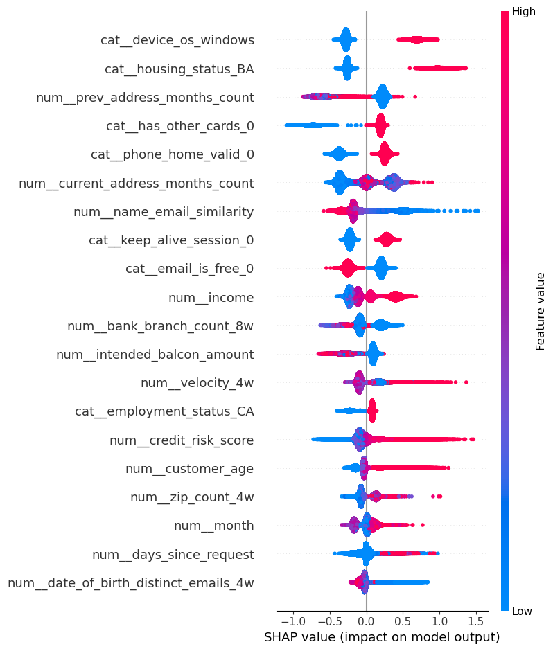

```python
shap.summary_plot(shap_values[1], features=X_test, max_display=20)
```

Ahora vamos a comentar los rasgos mas relevantes de este gráfico:

cat_device_os_windows: Los puntos rojos hacia la derecha indican que cuando la variable cat_device_os_windows es igual a 1 (es decir, cuando el sistema operativo del dispositivo es Windows), hay un mayor impacto positivo en la predicción del modelo hacia la clasificación de fraude. Esto sugiere que, según el modelo, las instancias con Windows tienen una mayor asociación con ser clasificadas como fraude.

Los puntos azules hacia la izquierda indican que cuando la variable cat_device_os_windows es 0 (o sea, cuando el sistema operativo del dispositivo no es Windows), hay un mayor impacto negativo en la predicción del modelo, lo cual empuja la clasificación hacia no fraude. Esto sugiere que las instancias sin Windows tienen una asociación con ser clasificadas como no fraude.

Esto pasa debido a que al ser una variable categorica con one hot encoding todas las instancias con 1 representan al sistema operativo windows mientras que las instancias con 0 el resto de sistemas operativos. Por lo tanto los rojos(high) son 1 y los azules(low) representan el valor 0.

Por lo tanto la presencia de Windows en el dispositivo se asocia con un riesgo más alto de fraude, mientras que la ausencia de Windows se asocia con un riesgo más bajo de fraude.

cat_housing_status_BA: Los puntos rojos asociados con la variable cat_housing_status_BA que están hacia la derecha del eje sugieren que cuando esta variable es 1 (es decir, el estado de vivienda corresponde a 'BA'), hay un mayor impacto positivo en la predicción de fraude del modelo. Esto indica que la condición de vivienda 'BA' está asociada con un mayor riesgo de fraude según el modelo.

Los puntos azules hacia la izquierda sugieren que cuando cat_housing_status_BA es 0 (el estado de vivienda no corresponde a 'BA'), hay un mayor impacto negativo en la predicción del modelo, desplazando la clasificación hacia no fraude. Esto indica que no tener la condición de vivienda 'BA' está asociado con un menor riesgo de fraude en el modelo.

Esto podría deberse a características demográficas o de comportamiento específicas asociadas con los solicitantes que tienen un estado de vivienda 'BA' que también se correlacionan con un mayor riesgo de fraude. Por ejemplo, si 'BA' representa un tipo de vivienda inestable o temporal, esto podría estar relacionado con un perfil de riesgo más alto.

num_prev_adress_months_count: La presencia de puntos rojos tanto en la izquierda como en la derecha sugiere que hay casos en los que un mayor número de meses en la dirección previa puede tener tanto un impacto positivo como negativo en la predicción del modelo. Esto podría indicar que la relación entre esta característica y el resultado del modelo no es lineal o que hay interacciones con otras variables que afectan su impacto.

cat_has_other_cards_0: Los puntos rojos hacia la derecha indican que cuando la característica cat_has_other_cards_0 es 1 (lo que implica que el cliente no tiene otras tarjetas), hay un impacto positivo en la predicción del modelo hacia la detección de fraude. En otras palabras, según el modelo, si un cliente no tiene otras tarjetas, esto se asocia con un mayor riesgo de fraude.

Los puntos azules hacia la izquierda sugieren que cuando la variable cat_has_other_cards_0 es 0 (es decir, el cliente sí tiene otras tarjetas), hay un impacto negativo en la predicción del modelo, orientándola hacia la no detección de fraude. Esto significa que, según el modelo, si un cliente tiene otras tarjetas, esto se asocia con un menor riesgo de fraude. Esto podria deberse a que los defraudadores evitan tener múltiples tarjetas para reducir su huella o riesgo de detección. También podría ser que aquellos que cometen fraude prefieren no dispersar su actividad fraudulenta en múltiples cuentas para maximizar el impacto en una sola cuenta.

cat_phone_home_valid_0: Los puntos rojos, que representan instancias donde cat_phone_home_valid_0 es 1, se desplazan hacia la derecha, esto sugiere que los teléfonos de casa no válidos están asociados con un aumento en la predicción de fraude. Esto podría deberse a que en los datos de entrenamiento, las instancias de fraude están frecuentemente relacionadas con información de contacto no válida o ficticia, lo que sería una táctica común entre los defraudadores para evitar el seguimiento o la verificación.

Los puntos azules, que representan instancias donde cat_phone_home_valid_0 es 0, se desplazan hacia la izquierda, esto indica que los teléfonos de casa válidos están asociados con una disminución en la predicción de fraude. Esto podría ser debido a que los clientes que proporcionan información de contacto válida son menos propensos a ser defraudadores, posiblemente porque la información legítima sugiere un perfil de cliente más fiable y verificable.

num_current_address_months_count: Los puntos rojos en el centro indican que hay observaciones con un alto número de meses en la dirección actual que no tienen un fuerte impacto en la dirección de la predicción (ni hacia la Clase 0 ni hacia la Clase 1). Esto puede deberse a que la duración en la dirección actual, por sí sola, no es un predictor consistente de la clase objetivo, o puede estar influenciada por la interacción con otras características. Los puntos rojos que se extienden hacia la derecha muestran que hay casos en los que el mismo alto número de meses tiene una influencia positiva en la probabilidad de la Clase 1. Esto significa que en algunas situaciones, la duración prolongada en la dirección actual puede ser interpretada por el modelo como un factor de riesgo o como una característica que está asociada con el resultado que define la Clase 1.Esto podría ser contraintuitivo, ya que normalmente esperaríamos que una mayor estabilidad residencial estuviera asociada con un menor riesgo de fraude. Una posible explicación podría ser que en los datos específicos del modelo, los casos de fraude identificados tenían un patrón de estabilidad residencial.

num_income: muestra una dispersión de puntos rojos predominantemente hacia la derecha, lo que indica que valores más altos de ingreso tienden a influir en el modelo para predecir la Clase 1. Los puntos azules, que representarían valores más bajos de ingreso, parecen estar más cerca del centro o ligeramente hacia la izquierda, sugiriendo que tienen un impacto neutral o negativo en la predicción de la Clase 1. Esto puede significar que según el modelo, un ingreso más alto aumenta la probabilidad de que una observación sea clasificada como de alto riesgo o fraudulenta.Lo mismo sucede con customer_age que cuanto mayor es la edad mayor es la probabilidad de hacer fraude.

Ahora nos centraremos en comprender cómo el modelo de aprendizaje automático toma decisiones a nivel de instancias individuales, específicamente para la instancia número 210 de nuestro conjunto de prueba. Utilizamos la técnica de explicabilidad local, que permite desglosar la predicción de una instancia específica en contribuciones de sus características individuales. Para hacer esto más manejable y enfocado, seleccionamos las 5 características más influyentes, basándonos en los valores SHAP absolutos, que representan la magnitud de impacto de cada característica en la predicción del modelo.

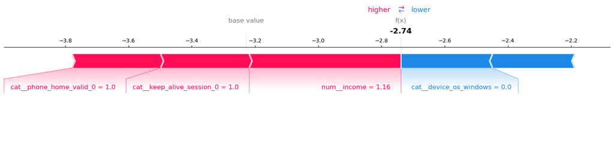

```python
num_features = 5
shap_vals = shap_values[1][209]
feature_order = np.argsort(np.abs(shap_vals))[::-1]
top_features = feature_order[:num_features]
top_shap_vals = np.round(shap_vals[top_features], decimals=2)
top_feature_data = np.round(X_test.iloc[209, top_features].values, decimals=2)
top_feature_data_rounded = pd.DataFrame([top_feature_data], columns=X_test.columns[top_features])

plt.figure(figsize=(20, 10))
shap.force_plot(explainer.expected_value[1], top_shap_vals, top_feature_data_rounded.iloc[0, :], matplotlib=True)
```

Las barras rojas representan características que contribuyen a una mayor probabilidad de fraude. En este gráfico, las características cat_phone_home_valid_0 y cat_keep_alive_session_0 tienen valores de aproximadamente 1.0 y num_income de 1.16 respectivamente, indicando que estas características incrementan ligeramente la probabilidad de que la instancia sea clasificada como fraude.

```python
shap.force_plot(explainer.expected_value[1], shap_values[1][:100,:], features=X_test.iloc[:100, :])
```

Por último vamos a mostrar la importancia de variables en nuestro modelo con SKlearn. Elaboramos el gráfico con el siguiente código.

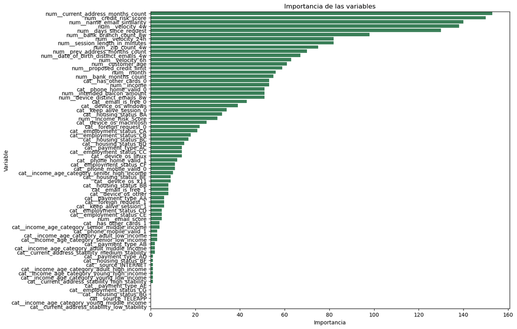

```python
lgbm_model = CV.best_estimator_.named_steps['classifier']
important_variables = lgbm_model.feature_importances_
feature_names = X_test.columns
importancia_variables = sorted(zip(feature_names, important_variables), key=lambda tup: tup[1], reverse=True)
importancia_variables_df = pd.DataFrame(importancia_variables, columns=['Variable', 'Importancia'])
plt.figure(figsize=(12, 10))
sns.barplot(x='Importancia', y='Variable', data=importancia_variables_df, color='seagreen')
plt.title('Importancia de las variables')
plt.show()
```

El análisis de la importancia de las variables utilizando el modelo LightGBM revela que los factores críticos para la predicción incluyen el número de meses en el domicilio actual, el score de crédito interno, la similitud entre el nombre y el email del solicitante, la frecuencia de solicitudes en las últimas 4 semanas (velocidad de solicitudes), el volumen de solicitudes en la sucursal bancaria en las últimas 8 semanas, la actividad de solicitud en las últimas 24 horas y la duración de la estancia en el domicilio previo. Adicionalmente, la longitud de la sesión del usuario en el sitio web del banco emerge como un indicador significativo.

Por otro lado, algunas variables que muestran un alto grado de influencia en los gráficos de SHAP, como el sistema operativo del dispositivo (Windows), la situación residencial (categoría BA), o la posesión de otras tarjetas de crédito, no aparecen con la misma intensidad de importancia en el gráfico de LightGBM. A pesar de que su relevancia no es tan prominente como en el análisis SHAP, estas variables todavía se mantienen como contribuyentes de peso en la modelización y no deben ser ignoradas.

La diferencia en la percepción de la importancia entre los métodos LightGBM y SHAP puede atribuirse a sus enfoques metodológicos inherentes. LightGBM determina la importancia de una variable basándose en la contribución global a la mejora del modelo, destacando las variables que mejor dividen el conjunto de datos y reducen el error de predicción. En cambio, SHAP calcula el impacto marginal de cada característica en las predicciones individuales, ofreciendo una perspectiva detallada de cómo las variables afectan el resultado del modelo en un nivel granular. Esto puede resultar en que SHAP resalte variables que tienen efectos más complejos y específicos de contexto, los cuales pueden no ser capturados plenamente por las métricas de importancia de variables tradicionales como las utilizadas en LightGBM.

A pesar de las diferencias observadas en la valoración de la importancia de las variables entre el modelo LightGBM y los análisis de SHAP, es esencial reconocer la utilidad y la perspectiva única que cada método aporta. Para obtener una comprensión exhaustiva y equilibrada del modelo, es prudente prestar atención a ambos enfoques. Los gráficos de importancia de LightGBM proporcionan una visión global de las características que más influyen en la mejora del modelo, mientras que los análisis de SHAP ofrecen una interpretación más detallada del impacto individual de cada variable en las predicciones específicas.

Condiderar ambos métodos nos permite capturar una imagen más completa y matizada del comportamiento del modelo, lo que resulta crucial para la la interpretación de sus decisiones.

En el último notebook sacaremos conclusiones acerca de esta información obtenida.